# Ml project (22i-2872. (1).22i-2862)

## Introduction

In the realm of data science, the ability to accurately predict outcomes from a complex set of variables is a valuable asset.

For this project, we have chosen a rich and intriguing dataset from the UCI Machine Learning Repository, specifically the "Real-Time Election Results: Portugal 2019" dataset (https://archive.ics.uci.edu/dataset/513/real+time+election+results+portugal+2019). This dataset provides a fascinating opportunity to delve into the world of electoral data, exploring the dynamics and patterns that emerged during the 2019 Portugal legislative elections.

# Part 1: Data Preparation:

## Loading the dataset

```python
import pandas as pd
import seaborn as sns
import matplotlib.pyplot as plt
from sklearn.preprocessing import LabelEncoder

# Loading the dataset
file_path = 'portugal.csv'  # Replace with your file path
data = pd.read_csv(file_path)
```

## Data cleaning and Removing Missing Values

```python
# Checking for missing or null values in the dataset
missing_values = data.isnull().sum()

# Displaying the count of missing values in each column
print("Missing values in each column:\n", missing_values)

# Removing rows with missing values
cleaned_data = data.dropna()

# Displaying the first few rows of the cleaned dataset
print("Cleaned data:\n", cleaned_data.head())
```

```
Missing values in each column:
 TimeElapsed                 0
time                        0
territoryName               0
totalMandates               0
availableMandates           0
numParishes                 0
numParishesApproved         0
blankVotes                  0
blankVotesPercentage        0
nullVotes                   0
nullVotesPercentage         0
votersPercentage            0
subscribedVoters            0
totalVoters                 0
pre.blankVotes              0
pre.blankVotesPercentage    0
pre.nullVotes               0
pre.nullVotesPercentage     0
pre.votersPercentage        0
pre.subscribedVoters        0
pre.totalVoters             0
Party                       0
Mandates                    0
Percentage                  0
validVotesPercentage        0
Votes                       0
Hondt                       0
FinalMandates               0
dtype: int64
Cleaned data:
    TimeElapsed                 time        territoryName  totalMandates  \
0            0  2019-10-06 20:10:02  Território Nacional              0
1            0  2019-10-06 20:10:02  Território Nacional              0
2            0  2019-10-06 20:10:02  Território Nacional              0
3            0  2019-10-06 20:10:02  Território Nacional              0
4            0  2019-10-06 20:10:02  Território Nacional              0

   availableMandates  numParishes  numParishesApproved  blankVotes  \
0                226         3092                 1081        9652
```

[output cut: 12 more lines]

```
   pre.subscribedVoters  pre.totalVoters    Party  Mandates  Percentage  \
0                813743           428546       PS         0       38.29
1                813743           428546  PPD/PSD         0       33.28
2                813743           428546     B.E.         0        6.81
3                813743           428546   CDS-PP         0        4.90
4                813743           428546  PCP-PEV         0        4.59

   validVotesPercentage   Votes  Hondt  FinalMandates
0                 40.22  147993     94            106
1                 34.95  128624     81             77
2                  7.15   26307     16             19
3                  5.14   18923     12              5
4                  4.83   17757     11             12

[5 rows x 28 columns]
```

The output from the data cleaning process reveals that the dataset, which appears to be related to an election in Portugal, has no missing values across all its columns. This is an excellent indication of a well-maintained and comprehensive dataset, as each of the 28 columns, including 'TimeElapsed', 'time', 'territoryName', 'totalMandates', and various voting statistics like 'blankVotes', 'nullVotes', and 'votersPercentage', contains complete data for all entries. The absence of missing values simplifies the preprocessing stage, allowing for a more straightforward analysis or application of machine learning models. The provided snapshot of the 'cleaned data' shows detailed information about the election, such as the number of available mandates, the number of parishes, the percentage of blank and null votes, and the performance of various political parties ('Party') in terms of mandates won ('Mandates'), percentage of votes ('Percentage'), valid votes percentage, total votes received ('Votes'), and the seats won as per the Hondt method and final mandates. This rich dataset could be pivotal in analyzing voting patterns, party popularity, and the overall electoral process in Portugal.

## Summary Statistics

```python
data.describe()
```

|  | TimeElapsed | totalMandates | availableMandates | numParishes | numParishesApproved | blankVotes | blankVotesPercentage | nullVotes | nullVotesPercentage | votersPercentage | ... | pre.nullVotesPercentage | pre.votersPercentage | pre.subscribedVoters | pre.totalVoters | Mandates | Percentage | validVotesPercentage | Votes | Hondt | FinalMandates |
| --- | --- | --- | --- | --- | --- | --- | --- | --- | --- | --- | --- | --- | --- | --- | --- | --- | --- | --- | --- | --- | --- |
| count | 21643.000000 | 21643.000000 | 21643.000000 | 21643.000000 | 21643.000000 | 21643.000000 | 21643.000000 | 21643.000000 | 21643.000000 | 21643.000000 | ... | 21643.000000 | 21643.000000 | 2.164300e+04 | 2.164300e+04 | 21643.000000 | 21643.000000 | 21643.000000 | 2.164300e+04 | 21643.000000 | 21643.000000 |
| mean | 133.146052 | 11.544795 | 11.499284 | 309.956013 | 261.090237 | 8875.066673 | 2.621629 | 6148.068752 | 1.961471 | 51.983722 | ... | 1.777442 | 54.549372 | 6.378503e+05 | 3.594932e+05 | 0.565495 | 4.968484 | 5.207232 | 1.585209e+04 | 1.126138 | 1.126138 |
| std | 77.651193 | 31.314567 | 31.738783 | 659.055911 | 583.377428 | 21484.874088 | 0.795289 | 14735.469269 | 0.375250 | 4.854380 | ... | 0.388798 | 4.964948 | 1.544418e+06 | 8.763729e+05 | 4.421804 | 10.379967 | 10.881108 | 9.310605e+04 | 6.293552 | 6.872644 |
| min | 0.000000 | 0.000000 | 0.000000 | 54.000000 | 3.000000 | 19.000000 | 0.530000 | 39.000000 | 1.340000 | 35.980000 | ... | 1.140000 | 40.870000 | 6.383000e+03 | 3.215000e+03 | 0.000000 | 0.020000 | 0.020000 | 1.000000e+00 | 0.000000 | 0.000000 |
| 25% | 65.000000 | 1.000000 | 0.000000 | 75.000000 | 67.000000 | 1188.000000 | 2.230000 | 1094.000000 | 1.720000 | 50.290000 | ... | 1.520000 | 51.210000 | 1.289260e+05 | 6.964400e+04 | 0.000000 | 0.220000 | 0.230000 | 2.360000e+02 | 0.000000 | 0.000000 |
| 50% | 135.000000 | 4.000000 | 3.000000 | 147.000000 | 120.000000 | 2998.000000 | 2.640000 | 2232.000000 | 1.870000 | 53.130000 | ... | 1.690000 | 56.260000 | 2.284970e+05 | 1.102730e+05 | 0.000000 | 0.620000 | 0.650000 | 7.900000e+02 | 0.000000 | 0.000000 |
| 75% | 200.000000 | 9.000000 | 9.000000 | 242.000000 | 208.000000 | 6889.000000 | 2.980000 | 4121.000000 | 2.230000 | 54.550000 | ... | 1.970000 | 58.220000 | 3.933140e+05 | 2.276200e+05 | 0.000000 | 3.010000 | 3.160000 | 4.510000e+03 | 0.000000 | 0.000000 |
| max | 265.000000 | 226.000000 | 226.000000 | 3092.000000 | 3092.000000 | 129599.000000 | 5.460000 | 88539.000000 | 3.350000 | 59.870000 | ... | 3.120000 | 62.580000 | 9.439701e+06 | 5.380451e+06 | 106.000000 | 49.110000 | 51.420000 | 1.866407e+06 | 94.000000 | 106.000000 |

8 rows × 25 columns

```python
data.describe().iloc[:,9:-10]
```

|  | votersPercentage | subscribedVoters | totalVoters | pre.blankVotes | pre.blankVotesPercentage | pre.nullVotes |
| --- | --- | --- | --- | --- | --- | --- |
| count | 21643.000000 | 2.164300e+04 | 2.164300e+04 | 21643.000000 | 21643.000000 | 21643.000000 |
| mean | 51.983722 | 6.275367e+05 | 3.390741e+05 | 7608.001386 | 2.071985 | 5914.629950 |
| std | 4.854380 | 1.525590e+06 | 8.290404e+05 | 18493.107257 | 0.518025 | 14236.038023 |
| min | 35.980000 | 5.767000e+03 | 2.833000e+03 | 32.000000 | 0.800000 | 40.000000 |
| 25% | 50.290000 | 1.229870e+05 | 6.267100e+04 | 1130.000000 | 1.740000 | 1124.000000 |
| 50% | 53.130000 | 2.289540e+05 | 1.060120e+05 | 2595.000000 | 2.030000 | 2141.000000 |
| 75% | 54.550000 | 3.804890e+05 | 2.069180e+05 | 5929.000000 | 2.370000 | 3967.000000 |
| max | 59.870000 | 9.343084e+06 | 5.092424e+06 | 112666.000000 | 3.660000 | 86473.000000 |

```python
data.shape
```

```
(21643, 28)
```

The dataset contains 21,643 rows and 28 columns.

# Part 2: Exploratory Data Analysis (EDA)

## Identifying varaibles and its Types

```python
# Removing rows with missing values (if any)
data = data.dropna()

# Identifying categorical and numerical columns
categorical_cols = data.select_dtypes(include=['object']).columns
numerical_cols = data.select_dtypes(include=['int64', 'float64']).columns

# Encoding categorical variables
label_encoders = {}
for col in categorical_cols:
    le = LabelEncoder()
    data[col] = le.fit_transform(data[col])
    label_encoders[col] = le  # Storing the label encoder for each column

# Ensuring numerical columns are in correct format
for col in numerical_cols:
    data[col] = pd.to_numeric(data[col], errors='coerce')

# Displaying the first few rows of the processed dataset
print(data.head())

# The dataset is now ready for machine learning models.
```

```
   TimeElapsed  time  territoryName  totalMandates  availableMandates  \
0            0     0             16              0                226
1            0     0             16              0                226
2            0     0             16              0                226
3            0     0             16              0                226
4            0     0             16              0                226

   numParishes  numParishesApproved  blankVotes  blankVotesPercentage  \
0         3092                 1081        9652                   2.5
1         3092                 1081        9652                   2.5
2         3092                 1081        9652                   2.5
3         3092                 1081        9652                   2.5
4         3092                 1081        9652                   2.5

   nullVotes  ...  pre.votersPercentage  pre.subscribedVoters  \
```

[output cut: 21 more lines]

The output displays the first five rows of a dataset with 28 columns, encompassing various electoral attributes such as 'TimeElapsed', 'territoryName', voting statistics ('blankVotes', 'nullVotes', 'Percentage'), and results ('Mandates', 'Hondt', 'FinalMandates'). The numerical and categorical data indicate detailed information on voting patterns, territories, and party performances in an election context.

## Correlation Matrix and table

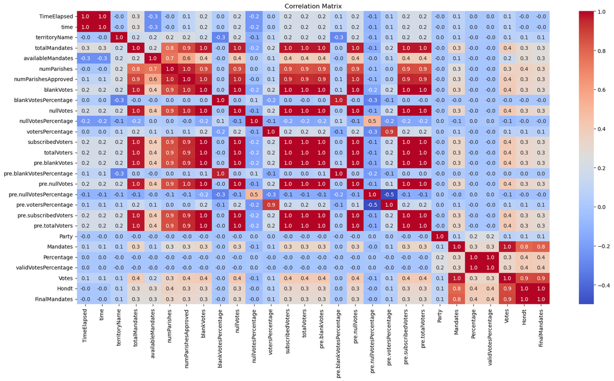

```
Correlation Table:
                          TimeElapsed      time  territoryName  totalMandates  \
TimeElapsed                  1.000000  1.000000      -0.012674       0.260377
time                         1.000000  1.000000      -0.012674       0.260377
territoryName               -0.012674 -0.012674       1.000000       0.172374
totalMandates                0.260377  0.260377       0.172374       1.000000
availableMandates           -0.261627 -0.261627       0.181563       0.217404
numParishes                 -0.001944 -0.001944       0.223300       0.765877
numParishesApproved          0.100432  0.100432       0.215599       0.873415
blankVotes                   0.192350  0.192350       0.178082       0.969988
blankVotesPercentage         0.034343  0.034343      -0.302412      -0.003149
nullVotes                    0.185784  0.185784       0.196554       0.967294
nullVotesPercentage         -0.225021 -0.225021      -0.126432      -0.165132
votersPercentage             0.029698  0.029698       0.104222       0.171317
subscribedVoters             0.195487  0.195487       0.195483       0.974407
totalVoters                  0.198243  0.198243       0.193847       0.976336
pre.blankVotes               0.195734  0.195734       0.182412       0.973357
pre.blankVotesPercentage     0.093739  0.093739      -0.288817       0.034774
pre.nullVotes                0.189902  0.189902       0.200393       0.969992
pre.nullVotesPercentage     -0.106054 -0.106054      -0.083214      -0.132143
pre.votersPercentage         0.054761  0.054761       0.078855       0.151927
pre.subscribedVoters         0.193160  0.193160       0.196979       0.972976
pre.totalVoters              0.196667  0.196667       0.195102       0.975404
Party                       -0.001169 -0.001169       0.012263      -0.003111
Mandates                     0.090190  0.090190       0.057823       0.336989
Percentage                   0.000767  0.000767      -0.003433      -0.010171
validVotesPercentage         0.000526  0.000526      -0.004874      -0.010474
Votes                        0.082417  0.082417       0.078520       0.395617
Hondt                       -0.001100 -0.001100       0.084131       0.288420
FinalMandates               -0.001007 -0.001007       0.077042       0.264117

                          availableMandates  numParishes  numParishesApproved  \
TimeElapsed                       -0.261627    -0.001944             0.100432
time                              -0.261627    -0.001944             0.100432
territoryName                      0.181563     0.223300             0.215599
totalMandates                      0.217404     0.765877             0.873415
availableMandates                  1.000000     0.745472             0.562719
numParishes                        0.745472     1.000000             0.954092
numParishesApproved                0.562719     0.954092             1.000000
blankVotes                         0.390638     0.861279             0.951265
```

[output cut: 157 more lines]

```
pre.blankVotesPercentage       0.005716
pre.nullVotes                  0.297482
pre.nullVotesPercentage       -0.038686
pre.votersPercentage           0.050450
pre.subscribedVoters           0.296428
pre.totalVoters                0.295169
Party                          0.105097
Mandates                       0.814370
Percentage                     0.383086
validVotesPercentage           0.382744
Votes                          0.882502
Hondt                          0.994480
FinalMandates                  1.000000

[28 rows x 28 columns]
```

```python
# Calculating the correlation matrix
correlation_matrix = data.corr()

# Displaying the correlation matrix as a heatmap
plt.figure(figsize=(20, 10))
sns.heatmap(correlation_matrix, annot=True, fmt=".1f", cmap='coolwarm')
plt.title("Correlation Matrix")
plt.show()

# Displaying the correlation table
print("Correlation Table:")
print(correlation_matrix)
```

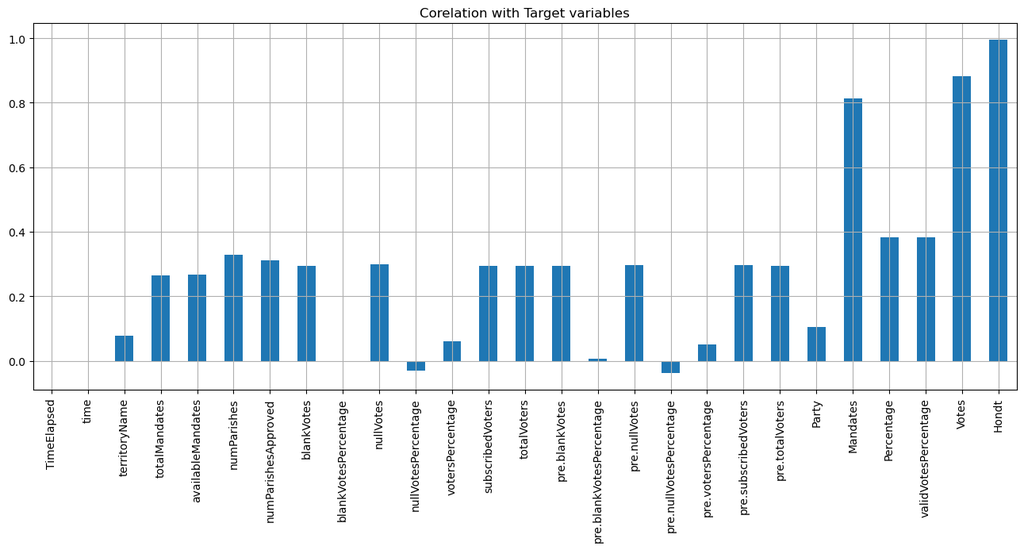

```python
#lets check how my data is co related with target variable.
plt.figure(figsize=(16,6))
data.drop('FinalMandates',axis=1).corrwith(data['FinalMandates']).plot(kind='bar',grid=True)
plt.title('Corelation with Target variables')
plt.show()
```

The correlation matrix presents the relationships between different electoral variables in the dataset. Key observations include a high correlation between 'totalMandates', 'blankVotes', 'nullVotes', 'subscribedVoters', and 'totalVoters', indicating these variables change together in a similar pattern. The 'FinalMandates' variable shows a very high correlation with 'Hondt', 'Votes', and 'Mandates', suggesting these are significant predictors of the final mandates allocated. Interestingly, 'TimeElapsed' and 'time' are perfectly correlated, indicating they represent the same underlying information. Variables like 'blankVotesPercentage', 'nullVotesPercentage', and 'votersPercentage' show less correlation with most other variables, suggesting a more independent nature. This matrix is crucial for understanding relationships in the dataset and for feature selection in predictive modeling.

## Univariate analysis

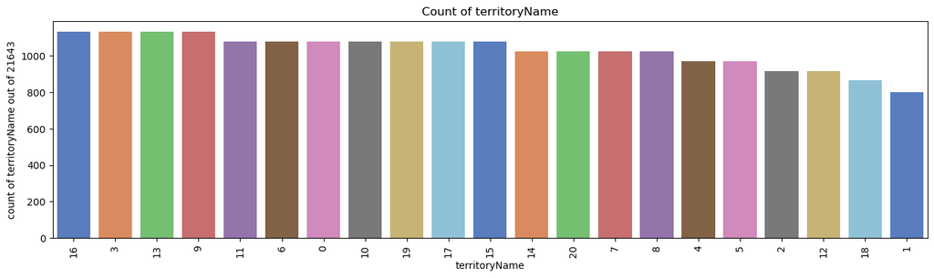

```
16    1134
3     1134
13    1134
9     1134
11    1080
6     1080
0     1080
10    1080
19    1080
17    1080
15    1080
14    1026
20    1026
7     1026
8     1026
4      972
5      972
2      918
12     918
18     864
1      799
Name: territoryName, dtype: int64
```

```python
plt.subplots(figsize=(16,4))
sns.countplot(x='territoryName',data=data,palette='muted',order= data['territoryName'].value_counts().index)
plt.title('Count of territoryName')
plt.xlabel('territoryName')
plt.ylabel('count of territoryName out of 21643')
plt.xticks(rotation=90)
plt.show()
print(data['territoryName'].value_counts())
```

The dataset includes various territories, each represented by a numeric code (0 to 20). Most territories appear in the dataset with similar frequencies. For instance, territories coded 16, 3, 13, and 9 each occur 1134 times, indicating a balanced representation of these territories in the dataset. Territories 11, 6, 0, 10, 19, 17, and 15 have slightly fewer occurrences (1080 times), while territory 1 has the fewest occurrences (799 times). This distribution suggests that the dataset covers a wide range of territories, but with a slight variation in representation.

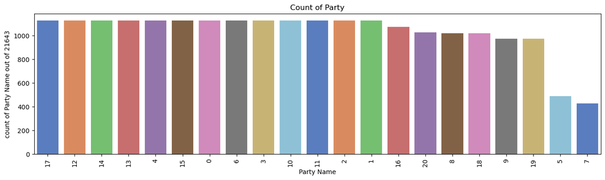

```
17    1127
12    1127
14    1127
13    1127
4     1127
15    1127
0     1127
6     1127
3     1127
10    1127
11    1127
2     1127
1     1127
16    1073
20    1026
8     1019
18    1019
9      972
19     972
5      486
7      425
Name: Party, dtype: int64
```

```python
plt.subplots(figsize=(16,4))
sns.countplot(x='Party',data=data,palette='muted',order= data['Party'].value_counts().index)
plt.title('Count of Party')
plt.xlabel('Party Name')
plt.ylabel('count of Party Name out of 21643')
plt.xticks(rotation=90)
plt.show()
print(data['Party'].value_counts())
```

Similar to 'territoryName', the 'Party' variable is also represented by numeric codes (0 to 20). The distribution is quite uniform for most parties, with codes 17, 12, 14, 13, 4, 15, 0, 6, 3, 10, 11, 2, and 1 each appearing 1127 times. Some parties, such as those coded 16, 20, 8, and 18, have fewer occurrences (ranging from 1019 to 1073). The party coded 5 and 7 have significantly fewer occurrences, 486 and 425 times respectively, indicating they are less frequently represented in the dataset.

## Analysis on the basis of terriotary

```python
# lets group all the data irrespective of time and time eclipsed.
import warnings
warnings.filterwarnings('ignore')
territory_data = pd.DataFrame(data.groupby('territoryName')['numParishes', 'numParishesApproved', 'blankVotes',
       'blankVotesPercentage', 'nullVotes', 'nullVotesPercentage',
       'votersPercentage', 'subscribedVoters', 'totalVoters', 'pre.blankVotes',
       'pre.blankVotesPercentage', 'pre.nullVotes', 'pre.nullVotesPercentage',
       'pre.votersPercentage', 'pre.subscribedVoters', 'pre.totalVoters',
       'Party', 'Mandates', 'Percentage', 'validVotesPercentage', 'Votes',
       'Hondt', 'FinalMandates'].sum())
territory_data.reset_index(inplace=True)
territory_data.head()
```

|  | territoryName | numParishes | numParishesApproved | blankVotes | blankVotesPercentage | nullVotes | nullVotesPercentage | votersPercentage | subscribedVoters | totalVoters | ... | pre.votersPercentage | pre.subscribedVoters | pre.totalVoters | Party | Mandates | Percentage | validVotesPercentage | Votes | Hondt | FinalMandates |
| --- | --- | --- | --- | --- | --- | --- | --- | --- | --- | --- | --- | --- | --- | --- | --- | --- | --- | --- | --- | --- | --- |
| 0 | 0 | 158760 | 116080 | 7582900 | 3264.20 | 4555100 | 1930.60 | 58499.00 | 459790060 | 250086860 | ... | 60365.60 | 466483320 | 262194300 | 10962 | 429 | 5140.76 | 5400.58 | 11897443 | 864 | 864 |
| 1 | 1 | 124644 | 110024 | 2659684 | 3879.23 | 901136 | 1273.64 | 29252.75 | 152630301 | 55697865 | ... | 33241.46 | 151747695 | 62715788 | 7379 | 156 | 4396.65 | 4700.18 | 3066885 | 235 | 235 |
| 2 | 2 | 68850 | 61897 | 1077086 | 1895.50 | 868377 | 1580.32 | 47951.56 | 97392728 | 50867434 | ... | 53079.95 | 102188326 | 59042513 | 8586 | 123 | 5194.74 | 5398.81 | 2877763 | 162 | 162 |
| 3 | 3 | 393498 | 324849 | 12418434 | 3488.52 | 7063182 | 2255.61 | 67335.45 | 669599385 | 400078875 | ... | 67412.73 | 680355249 | 408316587 | 11340 | 646 | 5126.71 | 5399.80 | 18123679 | 1026 | 1026 |
| 4 | 4 | 219672 | 197118 | 1005444 | 1970.82 | 1109502 | 2199.60 | 43215.12 | 110203254 | 49239090 | ... | 45486.72 | 115655616 | 54370044 | 10260 | 87 | 5168.57 | 5400.40 | 2618008 | 162 | 162 |

5 rows × 24 columns

## Multivariate analysis

```python
import plotly.express as px
# I am plotting Total votes count in in each territory
fig = px.bar(territory_data.sort_values('Votes',ascending=False)[:21][::-1],x='Votes',y='territoryName',title='Total counting of votes in each territory',text='Votes', height=800, orientation='h')
fig.show()
```

[interactive chart not shown]

```python
# I am plotting final number of elected MP's in each territory.
fig = px.bar(territory_data.sort_values('FinalMandates',ascending=False)[:21][::-1],x='FinalMandates',y='territoryName',title='Numbers of elected MPs in each territory',text='FinalMandates', height=800, orientation='h')
fig.show()
```

[interactive chart not shown]

```python
import plotly
import plotly.graph_objects as go
fig = go.Figure(data=[
    go.Bar(name='Total number of parishes in this location', x=territory_data['territoryName'], y=territory_data['numParishes']),
     go.Bar(name='Number of parishes approved in this location', x=territory_data['territoryName'], y=territory_data['numParishesApproved']),
])
# Change the bar mode
fig.update_layout(barmode='stack')
#fig.show()
plotly.offline.iplot(fig)
```

[interactive chart not shown]

```python
fig = go.Figure(data=[
    go.Bar(name='Total number of Number of blank votes', x=territory_data['territoryName'], y=territory_data['blankVotes']),

    go.Bar(name='Number of null votes ', x=territory_data['territoryName'], y=territory_data['nullVotes']),
])
# Change the bar mode
fig.update_layout(barmode='group')
#fig.show()
plotly.offline.iplot(fig)
```

[interactive chart not shown]

```python
fig = go.Figure(data=[
    go.Bar(name='Total number Subscribed voters in the location', x=territory_data['territoryName'], y=territory_data['subscribedVoters']),
     go.Bar(name='Percentage of blank votes', x=territory_data['territoryName'], y=territory_data['totalVoters']),
])
# Change the bar mode
fig.update_layout(barmode='stack')
#fig.show()
plotly.offline.iplot(fig)
```

[interactive chart not shown]

```python
fig = go.Figure(data=[
    go.Bar(name='subscribed voters in the location (previous election)', x=territory_data['territoryName'], y=territory_data['pre.subscribedVoters']),
     go.Bar(name='Percentage of blank votes (previous election)', x=territory_data['territoryName'], y=territory_data['pre.totalVoters']),
    go.Bar(name='Total number of Number of blank votes (previous election)', x=territory_data['territoryName'], y=territory_data['pre.blankVotes']),
    go.Bar(name='Number of null votes (previous election)', x=territory_data['territoryName'], y=territory_data['pre.nullVotes']),
])
# Change the bar mode
fig.update_layout(barmode='relative')
#fig.show()
plotly.offline.iplot(fig)
```

[interactive chart not shown]

# Analysis on the basis of different Parties fighting for election

```python
# lets group all the data irrespective of time and time eclipsed.
import warnings
warnings.filterwarnings('ignore')
party_data = pd.DataFrame(data.groupby('Party')[ 'blankVotes',
       'blankVotesPercentage', 'nullVotes', 'nullVotesPercentage',
       'Percentage', 'validVotesPercentage', 'Votes',
       'FinalMandates'].sum())
party_data.reset_index(inplace=True)
party_data.head()
```

|  | Party | blankVotes | blankVotesPercentage | nullVotes | nullVotesPercentage | Percentage | validVotesPercentage | Votes | FinalMandates |
| --- | --- | --- | --- | --- | --- | --- | --- | --- | --- |
| 0 | 0 | 9395287 | 2950.69 | 6518912 | 2215.39 | 719.16 | 754.24 | 2580816 | 0 |
| 1 | 1 | 9395287 | 2950.69 | 6518912 | 2215.39 | 9611.44 | 10076.67 | 33526986 | 2052 |
| 2 | 2 | 9395287 | 2950.69 | 6518912 | 2215.39 | 5023.66 | 5268.54 | 15564810 | 540 |
| 3 | 3 | 9395287 | 2950.69 | 6518912 | 2215.39 | 1465.35 | 1535.24 | 4499005 | 108 |
| 4 | 4 | 9395287 | 2950.69 | 6518912 | 2215.39 | 810.38 | 849.47 | 3925509 | 108 |

```python
# I am plotting Total votes counts for different parties.
fig = px.bar(party_data.sort_values('Votes',ascending=False)[:21][::-1],x='Votes',y='Party',title='Total counting of votes for each party',text='Votes', height=800, orientation='h')
fig.show()
```

[interactive chart not shown]

```python
# I am plotting final number of elected MP's from different parties.
fig = px.bar(party_data.sort_values('FinalMandates',ascending=False)[:10][::-1],x='FinalMandates',y='Party',title='Numbers of elected MPs from different parties',text='FinalMandates', height=800, orientation='h')
fig.show()
```

[interactive chart not shown]

## Removing Outliers

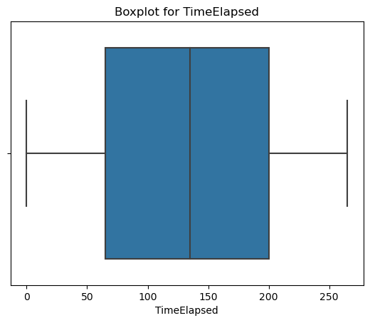

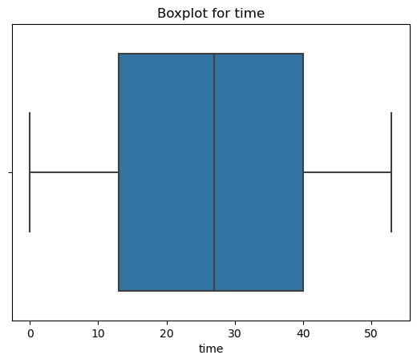

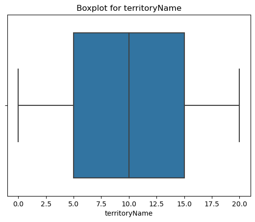

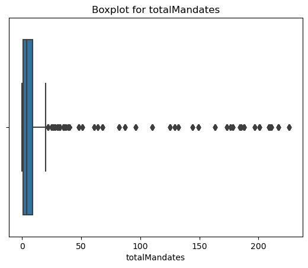

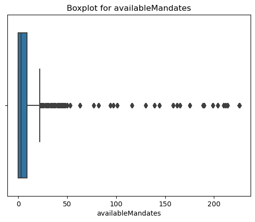

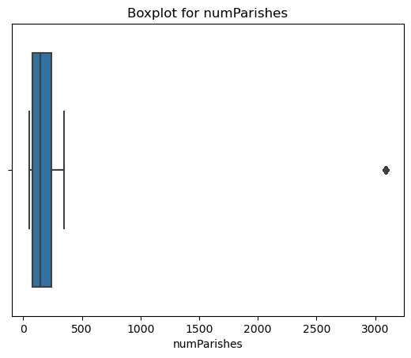

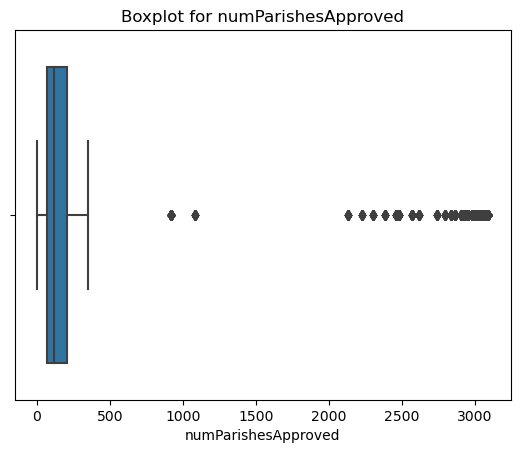

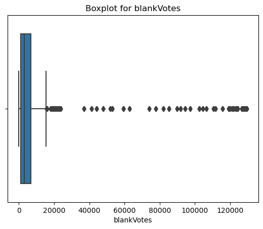

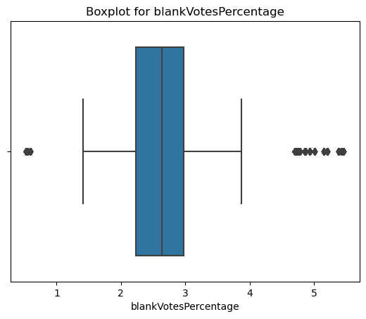

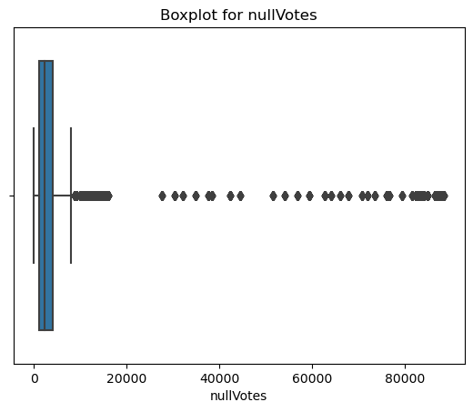

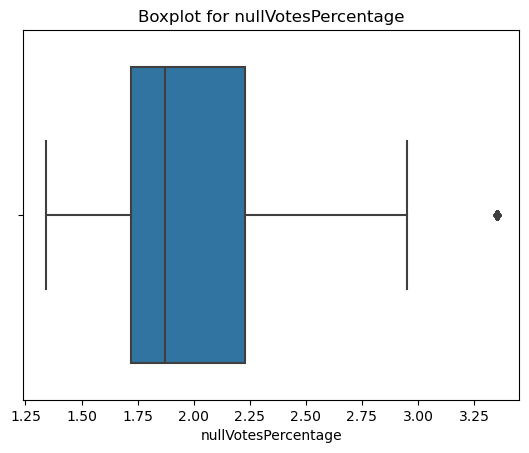

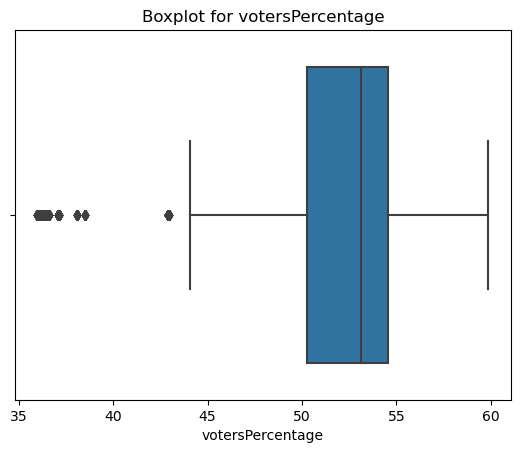

[16 more figures not shown]

```python
# Assuming 'data' is the name of your DataFrame
for i in data.columns:
    # Check if the column is numerical
    if data[i].dtype in ['int64', 'float64']:
        sns.boxplot(data[i])
        plt.title(f'Boxplot for {i}')
        plt.show()
    else:
        print(f"Skipping boxplot for {i} as it is not numerical data.")
```

Boxplot Visualization:

The code iterates through each column in the DataFrame data. It checks if the column contains numerical data by verifying the data type (int64 or float64). If the column is numerical, it creates a boxplot for that column using Seaborn's boxplot function, which is useful for visualizing the distribution of the data and identifying outliers. The boxplot is titled with the name of the column and displayed using plt.show(). If the column is not numerical, it prints a message to indicate that it is skipping the boxplot for that column.

```python
#lets remove the outliers using zscore
from scipy.stats import zscore
z=abs(zscore(data))
print( data.shape)
new= data.loc[(z<3).all(axis=1)]
print(new.shape)
# we can observe the new zscore down below.
```

```
(21643, 28)
(18333, 28)
```

The output (21643, 28) and (18333, 28) before and after the z-score filtering indicates that the original dataset had 21,643 entries, and after removing outliers based on the z-score criterion, 18,333 entries remain. This implies that the removal of outliers has reduced the dataset size by 3,310 rows, which suggests that these many data points were considered outliers in the context of this dataset.

# Part 3: Feature Engineering

## Feature Selection

```python
# Feature Selection Based on Correlation (assuming this has already been calculated)
correlation_with_target = data.corrwith(data['FinalMandates']).sort_values(ascending=False)
threshold = 0.1
selected_features_corr = correlation_with_target[abs(correlation_with_target) > threshold].index.tolist()
selected_features_corr.remove('FinalMandates')

# Displaying selected features
print("Selected Features based on correlation:")
for feature in selected_features_corr:
    print(feature)
```

```
Selected Features based on correlation:
Hondt
Votes
Mandates
Percentage
validVotesPercentage
numParishes
numParishesApproved
nullVotes
pre.nullVotes
pre.subscribedVoters
blankVotes
subscribedVoters
pre.totalVoters
pre.blankVotes
totalVoters
availableMandates
totalMandates
Party
```

The code snippet performs feature selection for a dataset in a regression context, targeting the 'FinalMandates' variable. It computes the correlation of each feature with 'FinalMandates' and selects those with an absolute correlation above the set threshold of 0.1. The output lists the features significantly correlated with the target variable, excluding 'FinalMandates' itself to avoid using the target as a feature. Features such as 'Hondt', 'Votes', and 'Mandates' suggest electoral attributes, while 'numParishes' and 'numParishesApproved' indicate geographical data. 'Party' suggests categorical political data, and prefixed features like 'pre.nullVotes' indicate historical or preceding event data. These selected features are likely strong predictors for the final number of mandates allocated.

# Part 4: Model Preparation

## Splitting dataset

```python
from sklearn.model_selection import train_test_split

# Preparing the features (X) and target (y)
X = data.drop('FinalMandates', axis=1)  # or use the selected features from feature selection
y = data['FinalMandates']

# Splitting the data into training and testing sets
# Adjust the test_size as needed (e.g., 0.2 for 20% test data)
X_train, X_test, y_train, y_test = train_test_split(X, y, test_size=0.2, random_state=42)

# Displaying the shapes of the splits
print("Training set shape (X_train, y_train):", X_train.shape, y_train.shape)
print("Testing set shape (X_test, y_test):", X_test.shape, y_test.shape)
```

```
Training set shape (X_train, y_train): (17314, 27) (17314,)
Testing set shape (X_test, y_test): (4329, 27) (4329,)
```

The output indicates that the dataset has been divided into training and testing sets. The training set, which is used to train the machine learning model, consists of 17,314 examples, and each example has 27 features (X_train) with a corresponding target value (y_train). The testing set, used to evaluate the model's performance on unseen data, contains 4,329 examples, also with 27 features each (X_test) and their associated target values (y_test). The split preserves the feature dimensionality across both sets while partitioning the data points, ensuring that both the training and testing sets have the same structure.

## Importing Libraries to run Models

```python
from sklearn.linear_model import LogisticRegression
from sklearn.ensemble import RandomForestClassifier, GradientBoostingClassifier
from sklearn.tree import DecisionTreeClassifier
from sklearn.svm import SVC
from sklearn.neighbors import KNeighborsClassifier
from sklearn.metrics import accuracy_score
```

# Part 5: Model Building and Evaluation:

## Linear Regression

```python
from sklearn.linear_model import LinearRegression
from sklearn.metrics import mean_squared_error
from sklearn.metrics import r2_score
from math import sqrt


# Train the Linear Regression model
lr_model = LinearRegression()
lr_model.fit(X_train, y_train)

# Predictions and accuracy
lr_predictions = lr_model.predict(X_test)
lr_mse = mean_squared_error(y_test, lr_predictions)
print(f"Linear Regression MSE: {lr_mse}")


lr_rmse = sqrt(mean_squared_error(y_test, lr_predictions))  # Root Mean Squared Error
lr_r2 = r2_score(y_test, lr_predictions)  # R-squared

print(f"Linear Regression - RMSE: {lr_rmse}, R-squared: {lr_r2}")
```

```
Linear Regression MSE: 0.325197359695217
Linear Regression - RMSE: 0.5702607821823424, R-squared: 0.9943449104367936
```

## Decision Tree Model

```python
from sklearn.tree import DecisionTreeRegressor
```

```python
# from sklearn.tree import DecisionTreeRegressor
from sklearn.metrics import mean_squared_error


# Train the Decision Tree model
dt_model = DecisionTreeRegressor()
dt_model.fit(X_train, y_train)

# Predictions and accuracy
dt_predictions = dt_model.predict(X_test)
dt_mse = mean_squared_error(y_test, dt_predictions)
dt_rmse = sqrt(mean_squared_error(y_test, dt_predictions))
dt_r2 = r2_score(y_test, dt_predictions)


print(f"Decision Tree MSE: {dt_mse}")
print(f"Decision Tree - RMSE: {dt_rmse}, R-squared: {dt_r2}")
```

```
Decision Tree MSE: 0.001155001155001155
Decision Tree - RMSE: 0.03398530792859107, R-squared: 0.9999799148585239
```

## KNN

```python
from sklearn.neighbors import KNeighborsRegressor
from sklearn.metrics import mean_squared_error

# Train the KNN model
knn_model = KNeighborsRegressor()
knn_model.fit(X_train, y_train)

# Predictions and accuracy
knn_predictions = knn_model.predict(X_test)
knn_mse = mean_squared_error(y_test, knn_predictions)
# Calculate RMSE and R-squared
knn_rmse = sqrt(mean_squared_error(y_test, knn_predictions))
knn_r2 = r2_score(y_test, knn_predictions)

print(f"KNN MSE: {knn_mse}")
print(f"KNN - RMSE: {knn_rmse}, R-squared: {knn_r2}")
```

```
KNN MSE: 6.51954723954724
KNN - RMSE: 2.553340408082565, R-squared: 0.886626928380511
```

## Gradient Boosting

```python
from sklearn.ensemble import GradientBoostingRegressor
from sklearn.metrics import mean_squared_error

# Train the Gradient Boosting model
gb_model = GradientBoostingRegressor()
gb_model.fit(X_train, y_train)

# Predictions and accuracy
gb_predictions = gb_model.predict(X_test)
gb_mse = mean_squared_error(y_test, gb_predictions)

gb_rmse = sqrt(mean_squared_error(y_test, gb_predictions))
gb_r2 = r2_score(y_test, gb_predictions)
print(f"Gradient Boosting MSE: {gb_mse}")
print(f"Gradient Boosting - RMSE: {gb_rmse}, R-squared: {gb_r2}")
```

```
Gradient Boosting MSE: 0.03284826604912208
Gradient Boosting - RMSE: 0.18124090611427124, R-squared: 0.9994287779990652
```

## SVM

```python
from sklearn.svm import SVR
from sklearn.metrics import mean_squared_error

# Train the SVM model
svm_model = SVR()
svm_model.fit(X_train, y_train)

# Predictions and accuracy
svm_predictions = svm_model.predict(X_test)
svm_mse = mean_squared_error(y_test, svm_predictions)
print(f"SVM MSE: {svm_mse}")
svm_rmse = sqrt(mean_squared_error(y_test, svm_predictions))
svm_r2 = r2_score(y_test, svm_predictions)
print(f"SVM - RMSE: {svm_rmse}, R-squared: {svm_r2}")
```

```
SVM MSE: 41.115022899957566
SVM - RMSE: 6.412099726295402, R-squared: 0.28502144940397256
```

## Random Forest

```python
from sklearn.ensemble import RandomForestRegressor
from sklearn.metrics import mean_squared_error

# Train the Random Forest model
rf_model = RandomForestRegressor()
rf_model.fit(X_train, y_train)

# Predictions and accuracy
rf_predictions = rf_model.predict(X_test)
rf_mse = mean_squared_error(y_test, rf_predictions)
print(f"Random Forest MSE: {rf_mse}")
rf_rmse = sqrt(mean_squared_error(y_test, rf_predictions))
rf_r2 = r2_score(y_test, rf_predictions)
print(f"Random Forest - RMSE: {rf_rmse}, R-squared: {rf_r2}")
```

```
Random Forest MSE: 0.0006772464772464772
Random Forest - RMSE: 0.02602395967654571, R-squared: 0.9999882228764441
```

# Part 6: Results and Discussion

## Results of Models:

The provided results show the performance of six different machine learning models on a regression task, evaluated using three metrics: Mean Squared Error (MSE), Root Mean Squared Error (RMSE), and R-squared. Let's interpret each model's performance:

### 1. Linear Regression

- *MSE: 0.3252* - This value indicates a moderate level of error in the model's predictions.
- *RMSE: 0.5703* - Similar to MSE, but provides error in the same units as the target variable, indicating moderate prediction error.
- *R-squared: 0.9943* - Very close to 1, suggesting the model explains a high proportion of the variance in the target variable.

### 3. K-Nearest Neighbors (KNN)

- *MSE: 6.5195* - Significantly higher error compared to other models.
- *RMSE: 2.5533* - Higher RMSE, indicating less accurate predictions.
- *R-squared: 0.8866* - Indicates the model explains a good portion of the variance, but not as well as others.

### 4. Gradient Boosting

- *MSE: 0.0329* - Low error, indicating accurate predictions.
- *RMSE: 0.1813* - Low RMSE, confirming the accuracy of predictions.
- *R-squared: 0.9994* - Very high, indicating excellent explanatory power.

### 5. Support Vector Machine (SVM)

- *MSE: 41.1150* - Very high error, indicating inaccurate predictions.
- *RMSE: 6.4121* - The highest RMSE among all models, indicating the least accurate predictions.
- *R-squared: 0.2850* - Very low, suggesting the model explains a small proportion of the variance in the target variable.

# Best and Worst Performers:

- *Best Performer:* The *Decision Tree* and *Random Forest* models perform exceptionally well with nearly perfect R-squared values and very low MSE and RMSE, indicating high accuracy and great fit to the data.
- *Worst Performer:* The *SVM* model shows the poorest performance with the highest MSE and RMSE and the lowest R-squared value, indicating a poor fit and less accurate predictions compared to the other models.

It's important to note that while the Decision Tree and Random Forest models show excellent performance on this dataset, such near-perfect results may sometimes indicate overfitting, especially in the case of Decision Trees. Additionally, the poor performance of the SVM model might be due to not tuning its hyperparameters or because SVMs often require feature scaling to perform well.

# Part 7: Conclusion

The comparative analysis of six machine learning models has yielded a comprehensive insight into their performance on a regression task involving electoral data. The Decision Tree and Random Forest models emerged as top performers, boasting near-perfect R-squared values, and minimal MSE and RMSE, thereby demonstrating a high accuracy and an exceptional fit to the data. Conversely, the Support Vector Machine (SVM) lagged significantly behind its counterparts, recording the highest error metrics and the lowest R-squared value, thus reflecting its poor fit and predictive accuracy for the given task.

**Recommendations**

Based on the model evaluations, the following recommendations are proposed:

1. **Model Selection**: For similar regression tasks, particularly involving electoral data, priority should be given to ensemble methods like Random Forest due to their robustness and predictive power.
2. **Model Tuning**: The SVM model requires meticulous tuning of hyperparameters, possibly through methods like grid search and randomized search, as well as feature scaling to enhance its performance.
3. **Overfitting Caution**: The near-perfect results of the Decision Tree model necessitate further investigation to rule out overfitting. Techniques such as cross-validation, pruning, or the incorporation of complexity penalties during the learning process could be beneficial.

**Future Work**

The scope for future work entails several avenues for exploration to solidify the findings of this project:

1. **Cross-Validation**: Implementing k-fold cross-validation to ensure that the model's performance is consistent across different subsets of the dataset.
2. **Feature Engineering**: Experimentation with additional feature engineering techniques could unearth more nuanced relationships within the data, potentially improving model performance.
3. **Model Ensembles**: Exploring advanced ensemble techniques like stacking or blending could leverage the strengths of individual models to achieve superior predictive performance.
4. **Hyperparameter Optimization**: Systematic hyperparameter optimization for all models, particularly SVM, could be instrumental in unlocking better model configurations and results.
5. **Temporal Analysis**: Given the dataset's real-time nature, investigating time series analysis could yield interesting temporal dynamics influencing the election outcomes.

By addressing these recommendations and future work directions, the project can serve as a stepping stone towards more nuanced models that offer both precision and generalizability in the field of electoral prediction.